# Polen Open Data

Momir Milutinovic

2020-08-05

This is a data analysis report about the pollen levels in Belgrade with the explanation of the R code used. Data that will be used for the analysis comes from the [pollen API](http://polen.sepa.gov.rs/api/opendata/schema), which is maintained by the [Environmental Protection Agency](http://sepa.gov.rs).

# Reading and organising data

We will start by reading in the data.

```r
> suppressPackageStartupMessages(library(dplyr))
> suppressPackageStartupMessages(library(ggplot2))
> suppressPackageStartupMessages(library(leaflet))
> suppressPackageStartupMessages(library(lubridate))
> library(tidyquant)
>
> mydata <- read.csv("pollenData.csv",
+                    header = T,
+                    stringsAsFactors = FALSE
+                    )
```

Let’s what we have here.

```r
> glimpse(mydata)
```

```
## Rows: 375,238
## Columns: 9
## $ X              <int> 1, 2, 3, 4, 5, 6, 7, 8, 9, 10, 11, 12, 13, 14, 15, 16,…
## $ id             <int> 6336, 6336, 6336, 6336, 6336, 6336, 6336, 6336, 6336, …
## $ date           <chr> "2017-02-06", "2017-02-06", "2017-02-06", "2017-02-06"…
## $ location_name  <chr> "БЕОГРАД - ЗЕЛЕНО БРДО", "БЕОГРАД - ЗЕЛЕНО БРДО", "БЕО…
## $ lat            <dbl> 44.8, 44.8, 44.8, 44.8, 44.8, 44.8, 44.8, 44.8, 44.8, …
## $ long           <dbl> 20.46667, 20.46667, 20.46667, 20.46667, 20.46667, 20.4…
## $ value          <int> 0, 0, 0, 0, 0, 0, 0, 0, 2, 7, 0, 0, 0, 0, 0, 0, 0, 0, …
## $ allergen_name  <chr> "ACER", "ALNUS", "AMBROSIA", "ARTEMISIA", "BETULA", "C…
## $ localized_name <chr> "ЈАВОР", "ЈОВА", "АМБРОЗИЈА", "ПЕЛИН", "БРЕЗА", "КОНОП…
```

We don’t really need the X and id columns at all.

```r
> mydata <- mydata[,-c(1, 2)]
> glimpse(mydata)
```

```
## Rows: 375,238
## Columns: 7
## $ date           <chr> "2017-02-06", "2017-02-06", "2017-02-06", "2017-02-06"…
## $ location_name  <chr> "БЕОГРАД - ЗЕЛЕНО БРДО", "БЕОГРАД - ЗЕЛЕНО БРДО", "БЕО…
## $ lat            <dbl> 44.8, 44.8, 44.8, 44.8, 44.8, 44.8, 44.8, 44.8, 44.8, …
## $ long           <dbl> 20.46667, 20.46667, 20.46667, 20.46667, 20.46667, 20.4…
## $ value          <int> 0, 0, 0, 0, 0, 0, 0, 0, 2, 7, 0, 0, 0, 0, 0, 0, 0, 0, …
## $ allergen_name  <chr> "ACER", "ALNUS", "AMBROSIA", "ARTEMISIA", "BETULA", "C…
## $ localized_name <chr> "ЈАВОР", "ЈОВА", "АМБРОЗИЈА", "ПЕЛИН", "БРЕЗА", "КОНОП…
```

That’s better! We will check how many unique records each variable in our data has.

```r
> (uniq <- unlist(lapply(mydata, function(x) length(unique(x)))))
```

```
##           date  location_name            lat           long          value
##            837             26             26             26            781
##  allergen_name localized_name
##             26             26
```

```r
> print(unique(mydata[, c("location_name", "lat", "long")]))
```

```
##                 location_name      lat     long
## 1       БЕОГРАД - ЗЕЛЕНО БРДО 44.80000 20.46667
## 6826   БЕОГРАД - НОВИ БЕОГРАД 44.82317 20.41291
## 13651                 КРАЉЕВО 43.72399 20.68891
## 20476                   ЧАЧАК 43.89270 20.34436
## 27301              КРАГУЈЕВАЦ 44.01181 20.91589
## 34126              НОВИ ПАЗАР 43.14081 20.51837
## 40951                КРУШЕВАЦ 43.58157 21.32034
## 47776                 ЗАЈЕЧАР 43.90631 22.27835
## 54601                 ЛОЗНИЦА 44.53713 19.22986
## 61426                    КУЛА 45.70159 19.38150
## 68251                СУБОТИЦА 46.10497 19.66857
## 75076                   БЕЧЕЈ 45.61306 20.05277
## 81901                   ВРШАЦ 45.11667 21.30361
## 88726                 ПАНЧЕВО 44.86823 20.65233
## 95551               ОБРЕНОВАЦ 44.65818 20.20004
## 102376              ПОЖАРЕВАЦ 44.62116 21.18908
## 109201               СОКОБАЊА 43.63953 21.86840
## 116026                  ВРАЊЕ 42.55146 21.90231
## 122851                    НИШ 43.31629 21.91368
## 129676               ЗЛАТИБОР 43.72186 19.70833
## 136501      СРЕМСКА МИТРОВИЦА 44.97161 19.61268
## 141997                  ВРБАС 45.57206 19.64030
## 147541                 СОМБОР 45.77914 19.11050
## 153061               ЗРЕЊАНИН 45.38223 20.39547
## 158533                КИКИНДА 45.83255 20.47846
## 164706                 ВАЉЕВО 44.27088 19.88723
```

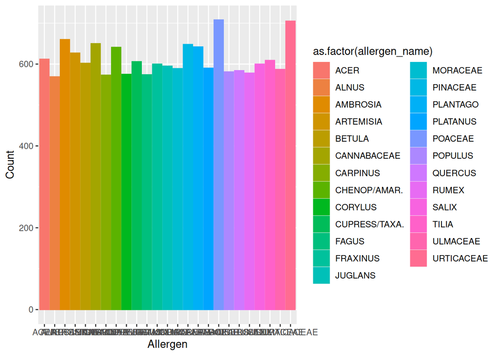

We seem to have almost even numbers of data points for each allegen.

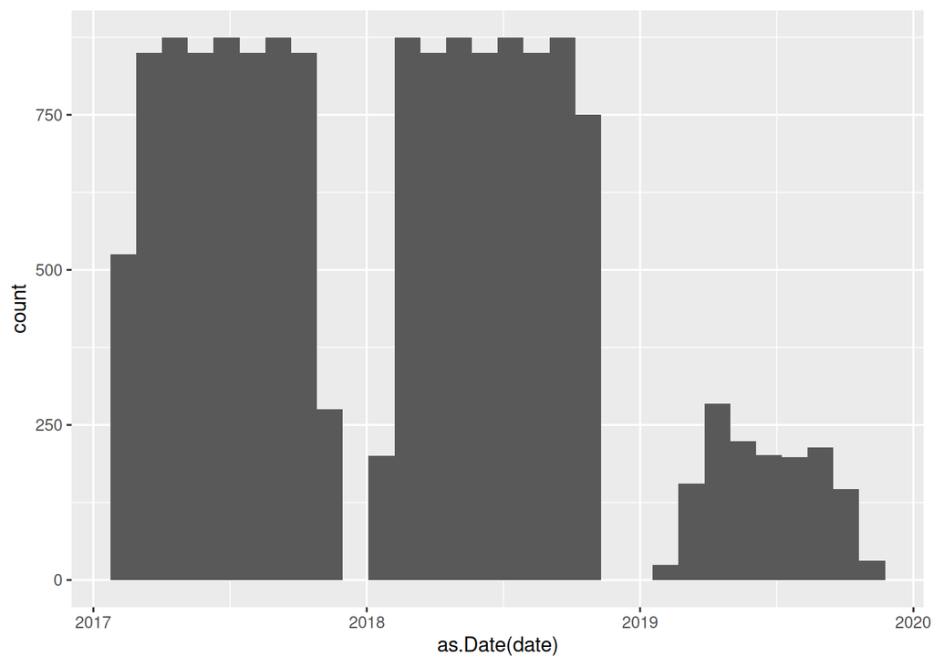

The more recent data seems to be more sparse, but we won’t be dealing with that here.

We will take a look at only the ambrosia data since different allergens might have different distributions as pictured above.

```r
> mydata <- mydata %>% filter(allergen_name == "AMBROSIA")
```

### Formatting date and time

Separate the year, month and day into separate columns

```r
>   mydata$date <- as.Date(mydata$date)
>   mydata <- mydata %>% mutate(year = lubridate::year(date))  %>%
+     mutate(month = lubridate::month(date)) %>%
+     mutate(day = lubridate::day(date))
```

### Adding next day

```r
>   mydata <- mydata %>% arrange(date)
>   mydata <- mydata %>% mutate(next_day = rollapply(mydata$value, width = 2, FUN = sum, fill = NA) - mydata$value)
>   # Remove last row that will have NA for next day
>   mydata <- mydata[is.na(mydata$next_day) == FALSE,]
```

# Analysing the readings

We will take a look at only the ambrosia data since different allergens might have different distributions as pictured above.

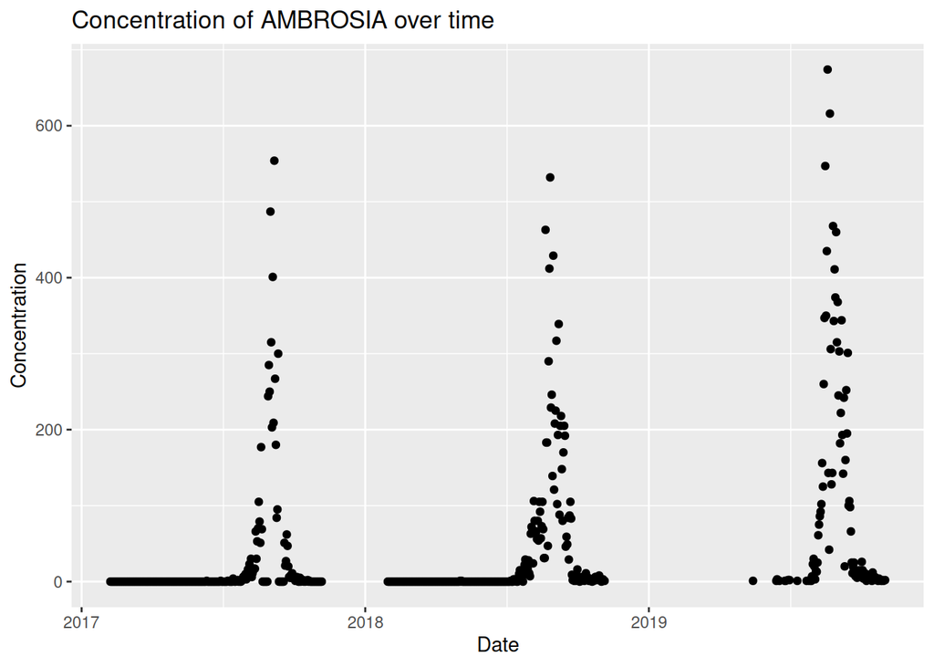

We can see some evenly spaced spikes. This is to be expected since there are pollen seasons during a year.

Let’s see the distribution of the concentration

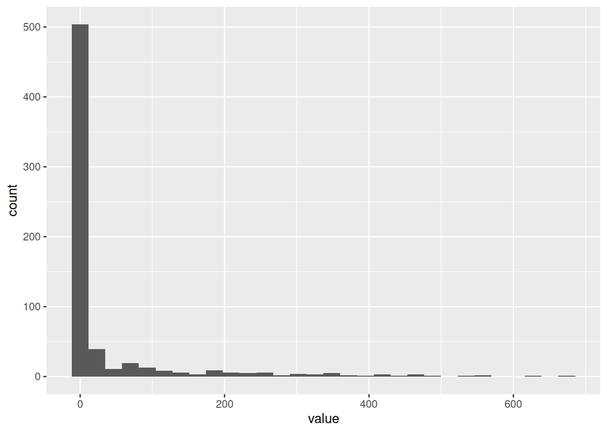

As is confirmed by the previous plot, we have lots of small values. This might be a problem for some learning algorithms.